# The impact of AI Adoption on Canadian Wage - Subtopic 2: Gender Equality

## *Did AI had an influence on wages and employments regarging gender equality?*

# Goals

In this analysis, we aim to investigate the impact of AI on gender equality in tech-related jobs. To achieve this goal, we intend to:

- Identify key patterns of gender inequality in employment over the years.
- Identify key patterns of gender inequality in wages over the years.
- Determine which occupations are the most discriminatory.

# Introduction

**Context/Hypothesis:** Before our analysis started, we hypothesized that AI would make the wage gap slightly fluctuates in an unknown direction and that the employment gap would be reduced even a little.

# Problem Statement

We wish to answer the following answers are the following:

- Do technology-related jobs in Canada continue to show a gender gap in employment and wages?
- What is the behaviour of these gender gaps over the last 13 years?
- Has the widespread introduction of AI had a disproportionate effect on employment trends or wages between men and women in these occupations?

**Significance:** The results can guide policy decisions related to recruitment, pay equity, and advancement opportunities by identifying which occupations remain most unequal.

```python
import warnings
import pandas as pd
import matplotlib.pyplot as plt
%matplotlib inline
```

## Getting started with the Employment and Wage dataset disaggregated by gender

**Data Context:**

The data is in a quite messy state with, the years in one of the first rows instead of the columns, the genders categories are used as delimiters spanning from the column they are until they encounter another category or the end. Those delimiters help determine the belonging of the numeric data.

Key variables include:

- Years: To track the data over time.
- NOC: To determine the different related occupations.
- Women+, Men+, Total - Gender: To determine the number of employments and ratio for each category.

Let's load the dataset and start ungrouping it according to what we need:

# Employment

```python
warnings.filterwarnings("ignore")

# Load the dataset
df = pd.read_csv("Gender1.csv", low_memory=False)

# Clean column names
df.columns = df.columns.str.strip()

# Create Subset 1 = first 40 columns
df_set1 = df.iloc[:, :40].copy()

# Only drop the first two junk rows; keep the year row
df_set1 = df_set1.drop(index=[0, 1], errors="ignore").reset_index(drop=True)

# Split Subset 1 into three column blocks
df_total = df_set1.iloc[:, 0:14].copy()                      # Total
df_men   = df_set1.iloc[:, [0] + list(range(14, 27))].copy() # Men
df_women = df_set1.iloc[:, [0] + list(range(27, 40))].copy() # Women
```

Then, our next step is to clean and do some transformations to our data:

# Data Cleaning and Data Transformation

First, we will create a function that will do the following:

- Drop all rows containing only missing values;
- Make each year correspond to a column;
- Melt the years into only one column named **Year**;
- Turn the years and data into numerical data
- Create a **Gender** column

Then, we will apply it to every one of our subset. We will concatenate them and do pivoting. Finally, we will create the columns **Women_Share_%** and **Gender_Employment_Gap_%**.

```python
def subset_to_long(df_subset, gender_label):
    df_tmp = df_subset.dropna(how="all").reset_index(drop=True)
    # Layout:
    # row 0: "15 years and over"
    # row 1: 2012, 2013, ...
    # row 2: "Persons in thousands"
    # row 3+: data rows
    years = df_tmp.iloc[1, 1:].tolist()
    data = df_tmp.iloc[3:, 1:].copy()
    data.columns = years

    long_df = data.melt(var_name="Year", value_name="Employment")
    long_df["Gender"] = gender_label

    long_df["Year"] = pd.to_numeric(long_df["Year"], errors="coerce")
    long_df["Employment"] = pd.to_numeric(long_df["Employment"], errors="coerce")
    long_df = long_df.dropna(subset=["Year", "Employment"]).reset_index(drop=True)
    return long_df

# Convert each block to long format
total_long = subset_to_long(df_total, "Total")
men_long   = subset_to_long(df_men,   "Men")
women_long = subset_to_long(df_women, "Women")

# Combine all into one tidy dataset
gender_long = pd.concat([total_long, men_long, women_long], ignore_index=True)

# Pivot: rows = Year, columns = Gender
pivot = gender_long.pivot_table(
    index="Year",
    columns="Gender",
    values="Employment",
    aggfunc="sum"
).reset_index()

pivot.columns.name = None

# Compute metrics
pivot["Women_Share_%"] = (pivot["Women"] / pivot["Total"]) * 100
pivot["Gender_Employment_Gap_%"] = ((pivot["Men"] - pivot["Women"]) / pivot["Men"]) * 100

# Every row will be displayed
pivot
```

|  | Year | Men | Total | Women | Women_Share_% | Gender_Employment_Gap_% |
| --- | --- | --- | --- | --- | --- | --- |
| 0 | 2012.0 | 1351.0 | 1740.4 | 389.4 | 22.374167 | 71.176906 |
| 1 | 2013.0 | 1385.3 | 1800.3 | 415.0 | 23.051714 | 70.042590 |
| 2 | 2014.0 | 1448.7 | 1889.4 | 440.8 | 23.330158 | 69.572720 |
| 3 | 2015.0 | 1460.0 | 1909.9 | 449.9 | 23.556207 | 69.184932 |
| 4 | 2016.0 | 1498.4 | 1946.1 | 447.9 | 23.015261 | 70.108115 |
| 5 | 2017.0 | 1518.9 | 1995.8 | 476.8 | 23.890169 | 68.608862 |
| 6 | 2018.0 | 1582.4 | 2082.9 | 500.6 | 24.033799 | 68.364510 |
| 7 | 2019.0 | 1700.7 | 2244.0 | 543.4 | 24.215686 | 68.048451 |
| 8 | 2020.0 | 1791.6 | 2404.2 | 612.3 | 25.467931 | 65.823845 |
| 9 | 2021.0 | 1975.4 | 2596.4 | 620.9 | 23.913881 | 68.568391 |
| 10 | 2022.0 | 2076.4 | 1704.6 | 683.8 | 40.114983 | 67.068002 |
| 11 | 2023.0 | 2057.8 | 1710.1 | 714.0 | 41.751944 | 65.302751 |
| 12 | 2024.0 | 2163.2 | 1790.3 | 741.7 | 41.428811 | 65.712833 |

The previous table shows the proportion of women employed in the job market and the gender gap between men and women in terms of percentage. Our next step will be to some data visualization.

# Data visualization

The following plot will represent the proportion of women in the job market over time.

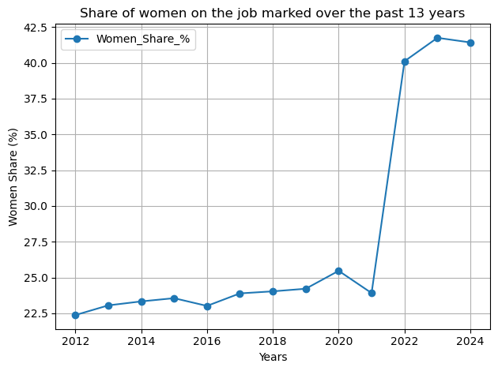

```python
# Plotting a line chart
plt.figure(figsize=(10, 6))
pivot.plot(kind="line", x="Year", y="Women_Share_%", marker='o')

# Setting up the parameters of the line plot
plt.title("Share of women on the job marked over the past 13 years")
plt.xlabel("Years")
plt.ylabel("Women Share (%)")
plt.grid(True)
plt.legend()
plt.tight_layout()
plt.savefig("figures/fig_1.png")

# Displaying the plot
plt.show();
```

According to the plot, it seems like women are increasingly involved in the job market over the years.

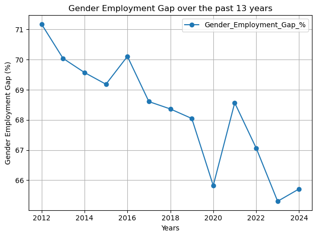

```python
# Plotting a line chart
plt.figure(figsize=(10, 6))
pivot.plot(kind="line", x="Year", y="Gender_Employment_Gap_%", marker='o')

# Setting up the parameters of the line plot
plt.title("Gender Employment Gap over the past 13 years")
plt.xlabel("Years")
plt.ylabel("Gender Employment Gap (%)")
plt.grid(True)
plt.legend()
plt.tight_layout()
plt.savefig("figures/fig_2.png")

# Displaying the plot
plt.show();
```

The chart shows a slight decreasing behaviour of gender employment gap over the years.

# Wages

Now, we are going to load and ungroup the dataset:

```python
# Load gender wage ratio subset
df = pd.read_csv("Gender_subset_2.csv", low_memory=False)
df.columns = df.columns.str.strip()


# ---------------------------------
# Define column indices (0-based)
#    Hourly ratio → Column(1; 28–40) → idx 0, 27–39
#    Weekly ratio → Column(1; 67–79) → idx 0, 66–78
# ---------------------------------
hourly_cols_idx = [0] + list(range(27, 40))  # occupation + hourly ratio years
weekly_cols_idx = [0] + list(range(66, 79))  # occupation + weekly ratio years

df_hourly = df.iloc[:, hourly_cols_idx].copy()
df_weekly = df.iloc[:, weekly_cols_idx].copy()
```

We unpacked the dataset into two subsets: one for the hourly wages and one for the weekly wages.

Our next step is to do data cleaning and transformation:

# Data Cleaning and Data Transformation

To clean our data, we are going to create a function that:

- Turns the rows into columns and group them into a single column named **Year**;
- Turns the values in **Year** and data into numerical data.
- Drop the missing values with respect to **Year** and **ratio**.

We will apply that function to each of the two previous datasets, merge those datasets and we will create three new columns: **Hourly_Wage_Gap_%**, **Weekly_Wage_Gap_%**, **Implied_Hours_Ratio**.

```python
warnings.filterwarnings("ignore")


# ---------------------------------
# Helper: reshape wide block → long by Year
#   Layout inside each block:
#      row 0: NaN
#      row 1: "Women+"
#      row 2: "15 years and over"
#      row 3: 2012, 2013, 2014, ...
#      row 4: NaN
#      row 5+: occupation + ratio values
# ---------------------------------
def reshape_ratio_block(df_block, value_name):
    # Row 3 contains year labels across columns 1..end
    years = df_block.iloc[3, 1:].tolist()

    # Data rows start at row 5 (0-based index)
    data = df_block.iloc[5:, 1:].copy()
    data.columns = years  # set year labels as column names

    # Occupation names live in column 0, same row indices (5+)
    data["Occupation"] = df_block.iloc[5:, 0].values

    # Melt wide → long
    long_df = data.melt(
        id_vars="Occupation",
        var_name="Year",
        value_name=value_name
    )

    # Clean types
    long_df["Year"] = pd.to_numeric(long_df["Year"], errors="coerce")
    long_df[value_name] = pd.to_numeric(long_df[value_name], errors="coerce")

    # Drop rows missing year or ratio
    long_df = long_df.dropna(subset=["Year", value_name]).reset_index(drop=True)

    return long_df


# Convert hourly & weekly to long
hourly_long = reshape_ratio_block(df_hourly, "Hourly_ratio")
weekly_long = reshape_ratio_block(df_weekly, "Weekly_ratio")


# Merge on Year + Occupation
wages = pd.merge(
    hourly_long,
    weekly_long,
    on=["Year", "Occupation"],
    how="inner"
)

# ---------------------------------
# Compute wage gap metrics (Methods section)
#   Ratios are Women-to-Men, so Men = 1.0
# ---------------------------------
wages["Hourly_Wage_Gap_%"] = (1 - wages["Hourly_ratio"]) * 100
wages["Weekly_Wage_Gap_%"] = (1 - wages["Weekly_ratio"]) * 100
wages["Implied_Hours_Ratio"] = wages["Weekly_ratio"] / wages["Hourly_ratio"]


# Inspect result
wages.head()
```

|  | Occupation | Year | Hourly_ratio | Weekly_ratio | Hourly_Wage_Gap_% | Weekly_Wage_Gap_% | Implied_Hours_Ratio |
| --- | --- | --- | --- | --- | --- | --- | --- |
| 0 | Natural and applied sciences and related occup... | 2012.0 | 0.89 | 0.85 | 11.0 | 15.0 | 0.955056 |
| 1 | Professional occupations in natural and applie... | 2012.0 | 0.90 | 0.86 | 10.0 | 14.0 | 0.955556 |
| 2 | Professional occupations in natural sciences | 2012.0 | 0.83 | 0.76 | 17.0 | 24.0 | 0.915663 |
| 3 | Professional occupations in applied sciences (... | 2012.0 | 0.96 | 0.93 | 4.0 | 7.0 | 0.968750 |
| 4 | Professional occupations in engineering | 2012.0 | 0.88 | 0.85 | 12.0 | 15.0 | 0.965909 |

We can now move on to the data visualization part:

# Data Visualization

The first thing is we will do some summary statistics of the data.

```python
# print some summary statistics
wages[["Hourly_ratio", "Weekly_ratio",
             "Hourly_Wage_Gap_%", "Weekly_Wage_Gap_%",
             "Implied_Hours_Ratio"]].describe()
```

|  | Hourly_ratio | Weekly_ratio | Hourly_Wage_Gap_% | Weekly_Wage_Gap_% | Implied_Hours_Ratio |
| --- | --- | --- | --- | --- | --- |
| count | 91.000000 | 91.000000 | 91.000000 | 91.000000 | 91.000000 |
| mean | 0.890000 | 0.855714 | 11.000000 | 14.428571 | 0.961010 |
| std | 0.034673 | 0.047915 | 3.467308 | 4.791527 | 0.026228 |
| min | 0.760000 | 0.680000 | 4.000000 | 6.000000 | 0.873563 |
| 25% | 0.880000 | 0.850000 | 9.000000 | 12.000000 | 0.955800 |
| 50% | 0.890000 | 0.860000 | 11.000000 | 14.000000 | 0.967033 |
| 75% | 0.910000 | 0.880000 | 12.000000 | 15.000000 | 0.977528 |
| max | 0.960000 | 0.940000 | 24.000000 | 32.000000 | 0.989247 |

Secondly, we are going to make line charts:

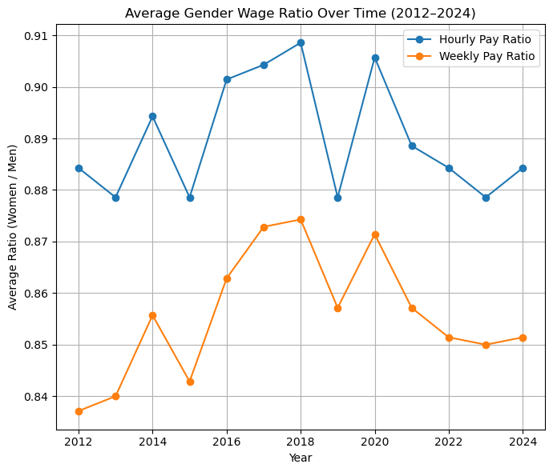

```python
warnings.filterwarnings("ignore")

# ----------------------------
# A. Trend Lines (Yearly trend)
# ----------------------------
avg_year = wages.groupby("Year")[["Hourly_ratio", "Weekly_ratio"]].mean()

plt.figure(figsize=(7,6))
plt.plot(avg_year.index, avg_year.Hourly_ratio, marker='o', label="Hourly Pay Ratio")
plt.plot(avg_year.index, avg_year.Weekly_ratio, marker='o', label="Weekly Pay Ratio")

plt.xlabel("Year")
plt.ylabel("Average Ratio (Women / Men)")
plt.title("Average Gender Wage Ratio Over Time (2012–2024)")
plt.grid(True)
plt.legend()
plt.tight_layout()
plt.savefig("figures/fig_3.png")

plt.show()
```

The shows that the Average wage ratio of women over men is oscillating over the years and does not have a steady pattern.

Let's now look at which jobs are the most discriminatory towards women with a horizontal bar plot:

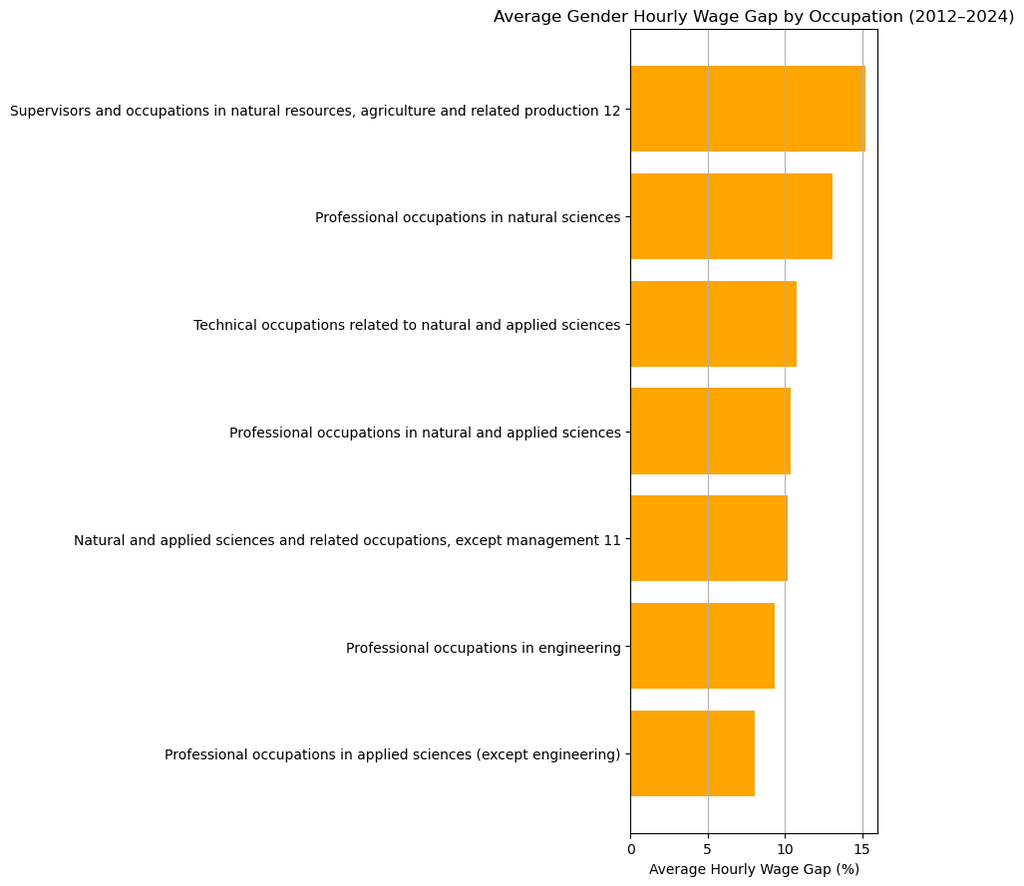

```python
# ----------------------------
# B. Horizontal bar
#   Hourly Gender wage gap vs Occupation
# ----------------------------
avg_gap = wages.groupby("Occupation")[["Hourly_Wage_Gap_%"]].mean().sort_values("Hourly_Wage_Gap_%")

plt.figure(figsize=(9,9))
plt.barh(avg_gap.index, avg_gap["Hourly_Wage_Gap_%"], color="orange")


plt.xlabel("Average Hourly Wage Gap (%)")
plt.title("Average Gender Hourly Wage Gap by Occupation (2012–2024)")
plt.grid(axis="x")
plt.tight_layout()
plt.savefig("figures/fig_4.png")
plt.show()
```

It appears that supervisors and occupations in natural resources, agriculture and related production are the most discriminatory in terms of wage gap between men and women.

Finally, we will do a scatter plot of the Weekly ratio vs the hourly ratio and do some summary statistics below:

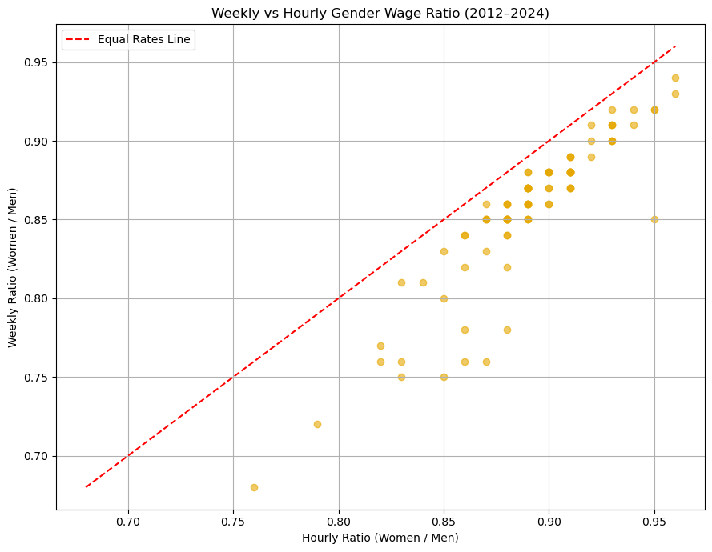

|  | Year | Hourly_ratio | Weekly_ratio | Hourly_Wage_Gap_% | Weekly_Wage_Gap_% | Implied_Hours_Ratio |
| --- | --- | --- | --- | --- | --- | --- |
| count | 91.000000 | 91.000000 | 91.000000 | 91.000000 | 91.000000 | 91.000000 |
| mean | 2018.000000 | 0.890000 | 0.855714 | 11.000000 | 14.428571 | 0.961010 |
| std | 3.762387 | 0.034673 | 0.047915 | 3.467308 | 4.791527 | 0.026228 |
| min | 2012.000000 | 0.760000 | 0.680000 | 4.000000 | 6.000000 | 0.873563 |
| 25% | 2015.000000 | 0.880000 | 0.850000 | 9.000000 | 12.000000 | 0.955800 |
| 50% | 2018.000000 | 0.890000 | 0.860000 | 11.000000 | 14.000000 | 0.967033 |
| 75% | 2021.000000 | 0.910000 | 0.880000 | 12.000000 | 15.000000 | 0.977528 |
| max | 2024.000000 | 0.960000 | 0.940000 | 24.000000 | 32.000000 | 0.989247 |

```python
# ----------------------------
# C. Scatter Plot
# Weekly vs Hourly Ratio
# ----------------------------

plt.figure(figsize=(9,7))
plt.scatter(wages["Hourly_ratio"], wages["Weekly_ratio"], alpha=0.6, c="#E6A800")

plt.xlabel("Hourly Ratio (Women / Men)")
plt.ylabel("Weekly Ratio (Women / Men)")
plt.title("Weekly vs Hourly Gender Wage Ratio (2012–2024)")
plt.grid(True)

# Plot 45-degree reference line
min_val = min(wages["Hourly_ratio"].min(), wages["Weekly_ratio"].min())
max_val = max(wages["Hourly_ratio"].max(), wages["Weekly_ratio"].max())
plt.plot([min_val, max_val], [min_val, max_val], 'r--', label="Equal Rates Line")

plt.legend()
plt.tight_layout()
plt.savefig("figures/fig_5.png")

plt.show()


# --------------------------------------------------------
# Optional: quick preview
# --------------------------------------------------------
wages.describe()
```

# Conclusion

Our analysis demonstrated that over the years, the employment gap between men and women have been reducing over time which is would be amazing especially if it was majoritarily due to the introduction of AI in the different tech-based occupations. Also, we found out that the wage gap between men and women has not really observed a steady pace which keeps questions lingering in our head such as: Is there something intefering with AI so that it negates its effects on gender gap? This analysis will allow employers to make better decisions regarding the process of making disappear the gender inequality.

# Key takeaways

In this case, we analyzed wage and employment gaps over the years and occupations using python. Specifically, we:

- Cleaned data related to wage and employment gap from the years 2012 to 2024;
- Grouped the data according to the data it is supposed to represent (wage/employment gap);
- Used visualizations and summary statistics to identify patterns.

The results encourage the fact that AI introduction is prone to reduce the employme gap difference but it is less certain for the wage gap difference because of the oscillations. Thus, the introduction of AI should be investigated further before making any real affirmations.